# Changes in School Attendance Zones over Time

The effect of segregation on Zoned-in and Zoned-out Areas

Authors

Affiliation

Magdalena Bennett  
*Principal Investigator*

The University of Texas at Austin

Anjali Bathra Ravikumar  
*Research Assistant*

The University of Texas at Austin

Published

March 16, 2023

Abstract

What happens to existing neighborhoods when new schools are built? This project aims to analyze the effect that changes in boundaries of school attendance zones have on new and existing schools, as well as neighborhoods at large. By combining housing pricing data over time, census data, school characteristics, and yearly school catchment areas, we will analyze how zones are affected by changes in their seeding neighborhoods. We will leverage new synthetic control methods to build valid causal counterfactuals in the presence of spillovers and assess the impact of changes in attendance zones on nearby areas. We will also use machine learning techniques to build individual predictions based on changes and the status quo of catchment areas to assess treatment effect heterogeneity. By shedding light on how choices of catchment areas have potential impacts on schools and neighborhoods, we expect to contribute to evidence-based policies that serve as critical input when making these decisions.

# Introduction

In the context of geographic segregation, schools play a fundamental role by either attracting or pushing away residents according to different socioeconomic characteristics (Hasan and Kumar 2019; Gibbons, Machin, and Silva 2013; Figlio and Lucas 2004). In that sense, the opening and closure of schools can lead to dramatic transformations in neighborhoods for current residents and families attracted to these new areas.

In this paper, we examine some of the core structural segregation that can arise or increase when there are changes in school attendance zones over time in Texas, zoning certain areas to better schools compared to others. The objective is to improve our understanding of what happens to existing schools and neighborhoods when new schools are built, focusing on the institutions and communities zoned out due to the appearance of a new attendance zone. In particular, we will analyze (i) changes in school composition and performance and (ii) changes in residential zones through housing prices. The central hypothesis of this paper is that in rapidly gentrified neighborhoods, new schools are more likely to appear to satisfy the demand of new residents for their “own” school. This phenomenon can lead to increased segregation at the school and neighborhood levels.

This paper will contribute to the literature on school and residential segregation and the complementarities of both phenomena on students and neighbors. In terms of school segregation, there has been an important focus on the effects of racial and socioeconomic disparities within schools and their impact on future outcomes (Reardon 2016; Billings, Deming, and Ross 2014). A relevant contribution of this paper is that we will be able to assess a school’s performance under different levels of segregation over time, leveraging the sorting that occurs when some students leave their original school to attend a new one. This project will also speak to the peer effects literature more broadly, assessing potential cream-skimming effects that occur with the introduction of new schools (Denning, Murphy, and Weinhardt 2021; Altonji, Huang, and Taber 2015; Dills 2005) . Regarding neighborhood segregation, authors have extensively shown that the characteristics of the neighborhood you live in affect different socioeconomic and labor outcomes for parents and their children (Chetty et al. 2020). If the introduction of a new school affects housing prices in a specific area, this change could increase or decrease socioeconomic and racial segregation. Given the geographic nature of the data we will be working with, it provides a robust setup to analyze changes in housing prices over time using variations in the attendance zones in general and leveraging the discontinuity in the newly created boundaries. At the same time, the availability of housing prices allows us to identify gentrification zones that could be more affected by the introduction of new schools.

Regarding geographic data, the use of attendance zones or district boundaries has been previously tackled in the literature to assess the effect of school characteristics on housing prices and students’ outcomes (Black 1999; Billings, Deming, and Ross 2014; Figlio and Lucas 2004). Our strategy follows some of this research, using repeated sales in properties over time to assess valuation with a specific focus on school composition. With this structure, we can assess how introducing a new school, which might not even be ranked yet, affects parental preferences, reflects on property prices, and impacts academic performance.

# Data

The data used for the analysis corresponds primarily to administrative data collected from multiple sources and harmonized as a large panel of schools and neighborhood characteristics between 2005 and 2019 in Texas. We combine data from different agencies, as well as geographic data over time to characterize neighborhoods. The sources used for this project are described below:

1. Common Core of Data (CCD): Information about schools over time, including demographic characteristics, location, and enrollment.
2. Texas Education Agency (TEA): Performance information for school each year (2010 onward), including Math and English test scores, SAT/ACT above criteria, and dropout rates.
3. Census data/ American Consumer Survey (ACS): Yearly information about census tracts socioeconomic characteristics (e.g. income, education, poverty, employment)
4. Attendance Zones (AZ): Finally, we use three different sources for attendance zones during this time period, including the School Attendance Boundary Survey (SABS) and the School Attendance Boundary Information System (SABINS), as well as more recent national attendance zones maps from Maponics. With this, we have attendance zones for the years 2009-2010, 2013-2014, and 2017 onward for larger districts in Texas.

In addition to the previously described data, we are collecting additional information about attendance zones over time to have a better geographic coverage of the state.

# Methodology

To study this problem, we will use a combination of Augmented Synthetic Control Method (ASCM) (Ben-Michael, Feller, and Rothstein 2021) and Synthetic Difference-in-Differences (SDD) (Arkhangelsky et al. 2021) to build sound counterfactuals, but also contributing methodologically to the literature by adapting these methods to account for spillover effects. In addition to a synthetic control approach, we will leverage the discontinuities at the boundaries of new attendance zones. Combining a difference-in-differences (DD) approach with a regression discontinuity design (RDD) provides an identification strategy that is stronger in terms of internal validity (Butts 2021; Bennett 2020), and could serve as an additional robustness check for previous strategies.

Given the political nature of some of the boundaries in catchment areas, where shifts in attendance zones potentially coincide with other changes, a sensitivity analysis to hidden bias is necessary to assess the robustness of our findings. The work of Keele, Small, and Foggarty (2019) and Yin et al. (2022) will inform sensitivity analysis to potential unobserved confounders in this setting, providing another methodological contribution on how to adapt these methods created for traditional difference-in-differences settings to more complex scenarios of SDD and ASCM in the presence of spillovers.

# Preliminary Results

## Measuring performance gaps

In this section, we show some results for the evolution of the gap on test scores between white and minority students for different levels, to capture potential segregation produced by the introduction of new schools..

### Comparing districts with new schools vs no new schools

For this analysis, we use all districts in Texas with at least 1 regular high school (public schools, excluding charter and magnet schools). We construct a panel of districts available between 2010 and 2018, comparing those that built one new school between 2013 and 2016.[^1] We use an Augmented Synthetic Control Method (ASCM) approach leveraging the staggered adoption of the introduction of new high schools, and analyze the evolution of the gap between white students and minority students (e.g. weighted average of performance by African American students and Hispanic students). Additionally, we control for relevant covariates such as: total number of schools in the district, average enrollment per school, average percentage of free or reduced price lunch students, average percentage of Hispanic, Asian, and African American.

The following plots show the differences in gaps over time between white students and minority students (i.e. Hispanic and African American). Figure 1 shows the evolution over time of the gap between white and minority students for proficiency scores (0-100) in Math comparing districts with a new school (treated) vs a synthetic control of districts which have not introduced a new high school. Figure 2 shows the same but for Reading. While we can observe a significant widening of the gap in Math for districts that introduce a new school, we find no significant effect for Reading.

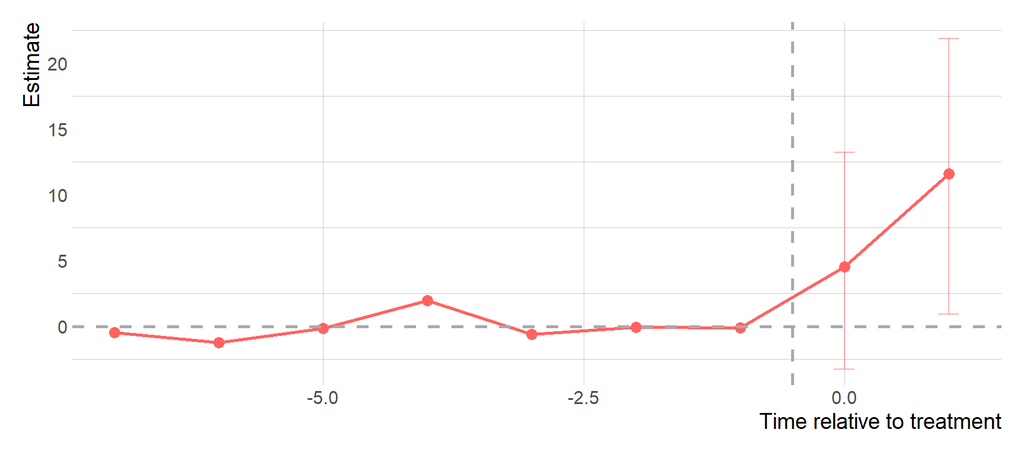

Figure 1: Estimated effect of a new school on the gap in Math proficiency (0-100) between white students and minority students - High Schools only

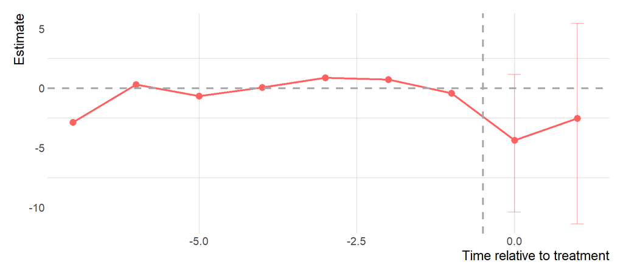

Figure 2: Estimated effect of a new school on the gap in Reading proficiency (0-100) between white students and minority students - High Schools only

One important thing to note is that the widening of a gap, in this case, could be attributed to the increase of proficiency for white students (relative to minority), the decrease in proficiency for minority students (relative to white students), or both.

## New high schools in Texas

The following map (Figure 3) shows all the districts that had **at least one new high school** in the period between 2010 and 2018. In this interactive map, the year indicates the school locations, identifying high schools that opened that year. Additionally, we can analyze changes in attendance zones by comparing attendance zones in the year 2009-2010, 2013-2014 and 2017-2018. We have also colored the attendance zones based on the school’s characteristics, in this case, the percentage of minority students (considered ,in this case, African American or Hispanic) enrolled that year.

[interactive chart not shown]

Figure 3: High schools in districts with at least one new school by year

## References

Altonji, Joseph, Ching-I Huang, and Christopher Taber. 2015. “Estimating Cream Skimming Effect of School Choice.” *Journal of Political Economy*.

Arkhangelsky, Dmitry, Susan Athey, David Hirshberg, Guido Imbens, and Stefan Wager. 2021. “Synthetic Difference-in-Differences.” *American Economic Review* 111 (12).

Ben-Michael, Elijah, Avi Feller, and Jesse Rothstein. 2021. “The Augmented Synthetic Control Method.” *Journal of the American Statistical Association*.

Bennett, Magdalena. 2020. “How Far Is Too Far? Generalization of a Regression Discontinuity Design Away from the Cutoff.” *Working Paper*.

Billings, Stephen, David Deming, and Jesse Ross. 2014. “School Segregation, Educational Attainment, and Crime: Evidence from the End of Busing in Charlotte-Mecklenburg.” *The Quarterly Journal of Economics*.

Black, Sandra. 1999. “Do Better Schools Matter? Parental Valuation of Elementary Education.” *The Quarterly Journal of Economics* 144 (2).

Butts, Kyle. 2021. “Geographic Difference-in-Discontinuities.” *Applied Economics Letters*.

Chetty, Raj, John Friedman, Nathaniel Hendren, Maggie Jones, and Sonya Porter. 2020. “The Opportunity Atlas: Mapping the Childhood Roots of Social Mobility.” *NBER Working Paper*.

Denning, Jeffrey, Richard Murphy, and Felix Weinhardt. 2021. “Class Rank and Long-Run Outcomes.” *The Review of Economics and Statistics*.

Dills, Angela. 2005. “Does Cream-Skimming Curdle the Milk? A Study of Peer Effects.” *Economics of Education Review*.

Figlio, David, and Maurice E Lucas. 2004. “What’s in a Grade? School Report Cards and Housing Markets.” *American Economic Review* 94 (3): 591–604.

Gibbons, Stephen, Stephen Machin, and Olmo Silva. 2013. “Valuing School Quality Using Boundary Discontinuities.” *Journal of Urban Economics* 73 (1): 70–85.

Hasan, Syed, and Anuj Kumar. 2019. “Digitization and Divergence: Online School Ratings and Segregation in America.” *SSRN Working Paper*.

Keele, Luke, Dylan Small, and Connor Foggarty. 2019. “Patterns of Effects and Sensitivity Analysis for Differences-in-Differences.” *Working Paper, arXiv*.

Reardon, Sean F. 2016. “School Segregation and Racial Academic Achievement Gaps.” *The Russel Sage Foundation Journal of the Social Sciences* 2 (4): 104–25.

Yin, Mingming, Chongming Shi, Yuling Wang, and David Blei. 2022. “Conformal Sensitivity Analysis for Individual Treatment Effects.” *Journal of the American Statistical Association*.

## Footnotes

[^1]: Schools that built more than one school or built a new school outside between 2010 and 2012 or 2017 and 2018 were excluded from the analysis